# LDA lab

```r
library(dplyr)  # optional
library(languageR)
library(tibble)  # optional
library(MASS)
```

# Discriminant analysis for a study in authorship attribution

The data set `spanishMeta` (from `LanguageR` library, “Analyzing Linguistic Data: A practical introduction to statistics”) contains metadata about fifteen texts sampled from three Spanish authors. Each line in this file provides information on a single text.

We will consider whether these authors can be distinguished on the basis of the quantitative characteristics of their personal styles (gauged by the relative frequencies of function words and tag trigrams).

## Data

Look at the help of `spanishMeta` data which are shown below.

```
   Author YearOfBirth  TextName PubDate Nwords    FullName
1       C        1916 X14458gll    1983   2972        Cela
2       C        1916 X14459gll    1951   3040        Cela
3       C        1916 X14460gll    1956   3066        Cela
4       C        1916 X14461gll    1948   3044        Cela
5       C        1916 X14462gll    1942   3053        Cela
6       M        1943 X14463gll    1986   3013     Mendoza
7       M        1943 X14464gll    1992   3049     Mendoza
8       M        1943 X14465gll    1989   3042     Mendoza
9       M        1943 X14466gll    1982   3039     Mendoza
10      M        1943 X14467gll    2002   3045     Mendoza
11      V        1936 X14472gll    1965   3037 VargasLLosa
12      V        1936 X14473gll    1963   3067 VargasLLosa
13      V        1936 X14474gll    1977   3020 VargasLLosa
14      V        1936 X14475gll    1987   3016 VargasLLosa
15      V        1936 X14476gll    1981   3054 VargasLLosa
```

1. A quick exercise of data manipulation
   1. Extract the column names from the data frame. Also extract the number of rows.
   2. Calculate how many different texts are available in meta for each author. Also calculate the mean publication date of the texts sampled for each author as well as for all texts.
   3. Sort the rows by year of birth and the number of words sampled from the texts.
   4. Sort the rows in meta by publication dates in descending order.
   5. Extract from meta all rows with texts that were published before 1980.

```
1.
[1] "Author"      "YearOfBirth" "TextName"    "PubDate"     "Nwords"
[6] "FullName"
[1] 15

2.
# A tibble: 3 x 3
  Author nText avgPubDate
  <fct>  <int>      <dbl>
1 C          5      1956
2 M          5      1990.
3 V          5      1975.
  avgPubDate
1     1973.6

3.
   Author YearOfBirth  TextName PubDate Nwords    FullName
1       C        1916 X14458gll    1983   2972        Cela
2       C        1916 X14459gll    1951   3040        Cela
3       C        1916 X14461gll    1948   3044        Cela
4       C        1916 X14462gll    1942   3053        Cela
5       C        1916 X14460gll    1956   3066        Cela
6       V        1936 X14475gll    1987   3016 VargasLLosa
7       V        1936 X14474gll    1977   3020 VargasLLosa
8       V        1936 X14472gll    1965   3037 VargasLLosa
9       V        1936 X14476gll    1981   3054 VargasLLosa
10      V        1936 X14473gll    1963   3067 VargasLLosa
11      M        1943 X14463gll    1986   3013     Mendoza
12      M        1943 X14466gll    1982   3039     Mendoza
13      M        1943 X14465gll    1989   3042     Mendoza
14      M        1943 X14467gll    2002   3045     Mendoza
15      M        1943 X14464gll    1992   3049     Mendoza

4. (just the head)
  Author YearOfBirth  TextName PubDate Nwords    FullName
1      M        1943 X14467gll    2002   3045     Mendoza
2      M        1943 X14464gll    1992   3049     Mendoza
3      M        1943 X14465gll    1989   3042     Mendoza
4      V        1936 X14475gll    1987   3016 VargasLLosa
5      M        1943 X14463gll    1986   3013     Mendoza
6      C        1916 X14458gll    1983   2972        Cela

5.
  Author YearOfBirth  TextName PubDate Nwords    FullName
1      C        1916 X14459gll    1951   3040        Cela
2      C        1916 X14460gll    1956   3066        Cela
3      C        1916 X14461gll    1948   3044        Cela
4      C        1916 X14462gll    1942   3053        Cela
5      V        1936 X14472gll    1965   3037 VargasLLosa
6      V        1936 X14473gll    1963   3067 VargasLLosa
7      V        1936 X14474gll    1977   3020 VargasLLosa
```

From each text, fragments of approximately $3000$ words were extracted. These text fragments were tagged, and the relative frequencies of tag trigrams were obtained. These relative frequencies are available as the data set `spanish`, rows (120) represent tag trigrams and columns (15) represent text fragments:

```
(Just first 5 rows and columns)
          X14461gll X14473gll X14466gll X14459gll X14462gll
P.A.N4     0.027494  0.006757  0.000814  0.024116  0.009658
VDA.J6.N5  0.000786  0.010135  0.003257  0.001608  0.005268
C.P.N5     0.008641  0.001126  0.001629  0.003215  0.001756
P.A.N5     0.118617  0.118243  0.102606  0.131833  0.118525
A.N5.JQ    0.011783  0.006757  0.014658  0.008039  0.000878
```

As we are interested in differences and similarities between texts, we transpose this matrix, so that we can consider the texts to be points in tag space:

```r
spanish_t <- t(spanish) %>% as.data.frame()
            P.A.N4 VDA.J6.N5   C.P.N5   P.A.N5  A.N5.JQ
X14461gll 0.027494  0.000786 0.008641 0.118617 0.011783
X14473gll 0.006757  0.010135 0.001126 0.118243 0.006757
X14466gll 0.000814  0.003257 0.001629 0.102606 0.014658
X14459gll 0.024116  0.001608 0.003215 0.131833 0.008039
X14462gll 0.009658  0.005268 0.001756 0.118525 0.000878
```

2. Rows of `spanish_t` must be synchronized with the author information in spanishMeta (also in view of next lda).

```r
spanishMeta$TextName
 [1] X14458gll X14459gll X14460gll X14461gll X14462gll X14463gll X14464gll X14465gll
 [9] X14466gll X14467gll X14472gll X14473gll X14474gll X14475gll X14476gll
15 Levels: X14458gll X14459gll X14460gll X14461gll X14462gll X14463gll ... X14476gll
rownames(spanish_t)
 [1] "X14461gll" "X14473gll" "X14466gll" "X14459gll" "X14462gll" "X14474gll"
 [7] "X14467gll" "X14475gll" "X14476gll" "X14463gll" "X14464gll" "X14460gll"
[13] "X14472gll" "X14465gll" "X14458gll"
```

One way through dplyr manipulation (not evaluated) is quite elaborated.

```r
spanish_ord <- spanish_t %>% rownames_to_column()
spanish_ord[1:5, 1:5]
    rowname   P.A.N4 VDA.J6.N5   C.P.N5   P.A.N5
1 X14461gll 0.027494  0.000786 0.008641 0.118617
2 X14473gll 0.006757  0.010135 0.001126 0.118243
3 X14466gll 0.000814  0.003257 0.001629 0.102606
4 X14459gll 0.024116  0.001608 0.003215 0.131833
5 X14462gll 0.009658  0.005268 0.001756 0.118525
spanish_ord <- spanish_ord %>% slice(match(spanishMeta$TextName, rowname))
spanish_ord[1:5, 1:5]
    rowname   P.A.N4 VDA.J6.N5   C.P.N5   P.A.N5
1 X14458gll 0.016043  0.000000 0.008913 0.105169
2 X14459gll 0.024116  0.001608 0.003215 0.131833
3 X14460gll 0.042509  0.000000 0.002787 0.119861
4 X14461gll 0.027494  0.000786 0.008641 0.118617
5 X14462gll 0.009658  0.005268 0.001756 0.118525
spanish_ord <- spanish_ord %>% column_to_rownames()
spanish_ord[1:5, 1:5]
            P.A.N4 VDA.J6.N5   C.P.N5   P.A.N5  A.N5.JQ
X14458gll 0.016043  0.000000 0.008913 0.105169 0.014260
X14459gll 0.024116  0.001608 0.003215 0.131833 0.008039
X14460gll 0.042509  0.000000 0.002787 0.119861 0.013240
X14461gll 0.027494  0.000786 0.008641 0.118617 0.011783
X14462gll 0.009658  0.005268 0.001756 0.118525 0.000878
```

Find another way, e.g., the classical one:

```r
spanish_t <- spanish_t ???
```

```
            P.A.N4 VDA.J6.N5   C.P.N5   P.A.N5  A.N5.JQ
X14458gll 0.016043  0.000000 0.008913 0.105169 0.014260
X14459gll 0.024116  0.001608 0.003215 0.131833 0.008039
X14460gll 0.042509  0.000000 0.002787 0.119861 0.013240
X14461gll 0.027494  0.000786 0.008641 0.118617 0.011783
X14462gll 0.009658  0.005268 0.001756 0.118525 0.000878
```

It is instructive to begin with an unsupervised exploration of these data, for instance with principal components analysis (PCA):

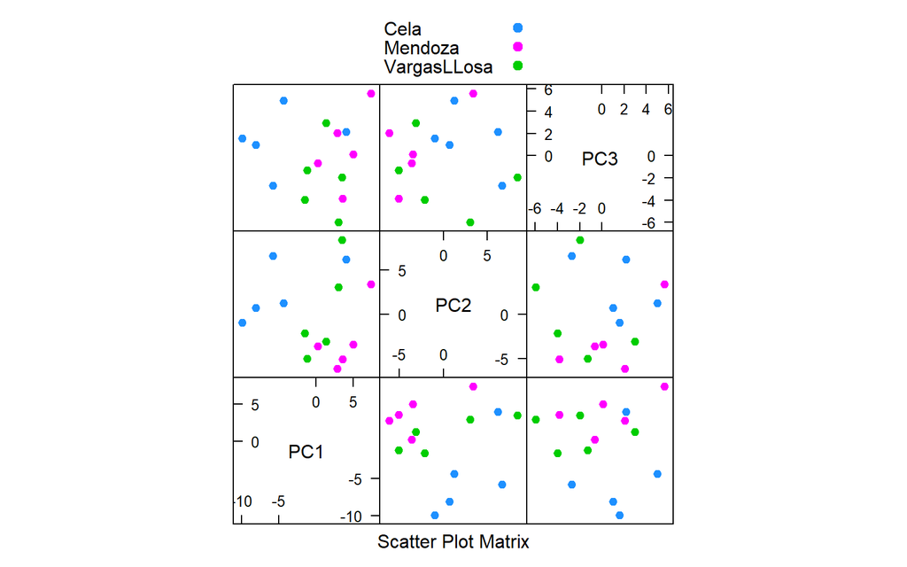

```r
spanish_pca <- prcomp(spanish_t, scale = T)
spanish_x <- data.frame(spanish_pca$x)
spanish_x[1:5, 1:5]
                PC1        PC2       PC3        PC4       PC5
X14458gll -5.779893  6.6309396 -2.705098  1.1077649 -2.798319
X14459gll -4.341274  1.2322996  4.983803 -5.6972605  3.567688
X14460gll -9.909489 -0.9632382  1.565260  0.5826788  3.121576
X14461gll -8.086999  0.6945747  0.981219 -1.0040776 -6.142975
X14462gll  4.017537  6.1854522  2.167760  0.3095874  1.181440

library(lattice)
splom(spanish_x[, 1:3], groups = spanishMeta$Author, pch = 19, col = c("dodgerblue", "magenta",
    "green3"), key = list(text = list(levels(spanishMeta$FullName)), points = list(pch = 19,
    col = c("dodgerblue", "magenta", "green3"))))
```

Cela and Mendoza occupy different regions in the plane spanned by PC1 and PC2. VargasLLosa, however, seems to be indistinguishable from the other two authors.

Let’s now replace unsupervised clustering by supervised classification.

## LDA

The function for LDA, `lda`, is contained in the MASS package. `lda` takes two arguments, the matrix of numerical predictors and a vector with class labels.

A first attempt comes with a warning about collinearity:

```r
spanish_lda = lda(spanish_t, spanishMeta$Author)
Warning in lda.default(x, grouping, ...): variables are collinear
```

The columns in `spanish_t` are too correlated for `lda` to work properly. We therefore continue our analysis with the first eight principal components, which, as revealed by the summary of the pca object, capture almost 80% of the variance in the data. These principal components are, by definition, uncorrelated, so the warning message should disappear.

```r
summary(spanish_pca)
Importance of components:
                          PC1    PC2     PC3     PC4     PC5     PC6     PC7     PC8
Standard deviation     5.0623 4.6688 3.34736 3.01422 2.84788 2.73612 2.61125 2.38516
Proportion of Variance 0.2136 0.1817 0.09337 0.07571 0.06759 0.06239 0.05682 0.04741
Cumulative Proportion  0.2136 0.3952 0.48858 0.56429 0.63188 0.69427 0.75109 0.79850
                           PC9    PC10    PC11    PC12    PC13    PC14      PC15
Standard deviation     2.37170 2.22456 2.06076 1.95823 1.82924 1.47628 1.382e-15
Proportion of Variance 0.04687 0.04124 0.03539 0.03196 0.02788 0.01816 0.000e+00
Cumulative Proportion  0.84537 0.88661 0.92200 0.95395 0.98184 1.00000 1.000e+00
```

3. Fit the LDA with the first 8 PCs and plot the linear discrimants.

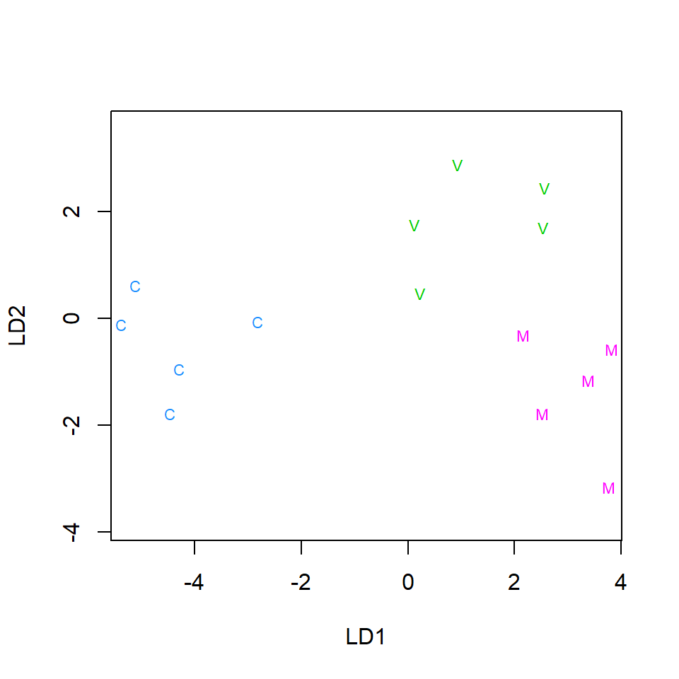

```r
spanish_pca_lda <- lda(???)
plot(???)
```

The figure above shows a clear separation of the texts by author. We can query the model for the probability with which it assigns texts to authors with `predict`, supplied with the model object as first argument, and the input data as second argument. A table with the desired probabilities is available under the name posterior, which we round to four decimal digits for ease of interpretation:

```r
predict(spanish_pca_lda)$posterior %>% round(4)
               C      M      V
X14458gll 1.0000 0.0000 0.0000
X14459gll 1.0000 0.0000 0.0000
X14460gll 1.0000 0.0000 0.0000
X14461gll 1.0000 0.0000 0.0000
X14462gll 0.9999 0.0000 0.0001
X14463gll 0.0000 0.9988 0.0012
X14464gll 0.0000 1.0000 0.0000
X14465gll 0.0000 0.9965 0.0035
X14466gll 0.0000 0.9992 0.0008
X14467gll 0.0000 0.8416 0.1584
X14472gll 0.0000 0.0001 0.9998
X14473gll 0.0000 0.0000 1.0000
X14474gll 0.0000 0.0014 0.9986
X14475gll 0.0000 0.0150 0.9850
X14476gll 0.0001 0.0112 0.9887
```

It is clear that each text is assigned to its own author with a very high probability.

Unfortunately, this table is rather misleading because the model seriously overfits the data.

4. The confusion matrix and the training error rate are:

```
confusion matrix:

    C M V
  C 5 0 0
  M 0 5 0
  V 0 0 5
Cases correctly classified:
[1] 15
Training error rate:
[1] 0
```

The existence of a problem lurking in the background can be indicated by scrutinizing the group means.

```r
spanish_pca_lda$means
        PC1        PC2        PC3         PC4        PC5         PC6        PC7
C -4.820024  2.7560056  1.3985890 -0.94026140 -0.2141179 -0.02702131 -0.5425466
M  3.801425 -2.9890677  0.6494555 -0.01748498 -0.4472681  1.75549883 -0.6416654
V  1.018598  0.2330621 -2.0480445  0.95774638  0.6613860 -1.72847752  1.1842120
          PC8
C  0.86906543
M  0.09646039
V -0.96552582
```

There are differences among these group means, but they are not that large, and we may wonder whether any are actually significant.

```r
spanish_manova = manova(cbind(PC1, PC2, PC3, PC4, PC5, PC6, PC7, PC8) ~ spanishMeta$Author,
    data = spanish_x)
summary(spanish_manova)
                   Df Pillai approx F num Df den Df  Pr(>F)
spanishMeta$Author  2 1.6283   3.2854     16     12 0.02134 *
Residuals          12
---
Signif. codes:  0 '***' 0.001 '**' 0.01 '*' 0.05 '.' 0.1 ' ' 1
```

In order to gauge the extent to which our results might generalize, we carry out a leave-one-out cross-validation (LOOCV).

Although `lda` has an option for carrying out LOOCV (CV=TRUE), we cannot use this option here because the orthogonalization of our input (resulting in `spanish_x`) takes the data from all authors and all texts into account.

We run fifteen different discriminant analyses, each of which is trained on fourteen texts and is used to predict the author of the remaining held-out text. The proportion of correct attributions will give us improved insight into how well the model would perform when confronted with new texts by one of these three authors.

```r
n <- nrow(spanish_t)
predictedClasses = rep("", n)

for (i in 1:n) {
    training = spanish_t[-i, ]
    trainingAuthor = spanishMeta[-i, ]$Author
    training_pca = prcomp(training, scale = T)
    training_x = data.frame(training_pca$x)
    training_pca_lda = lda(training_x[, 1:k], trainingAuthor)
    predictedClasses[i] = as.character(predict(training_pca_lda, spanish_x[i, 1:k])$class)
}
```

We compare the observed and predicted authors:

```
   obs pred
1    C    M
2    C    C
3    C    C
4    C    C
5    C    V
6    M    M
7    M    M
8    M    M
9    M    M
10   M    V
11   V    V
12   V    V
13   V    V
14   V    V
15   V    M
```

The number of correct attributions is

```
[1] 11
```

### Correct CV

```r
for (i in 1:n) {
    training = spanish_t[-i, ]
    trainingAuthor = spanishMeta[-i, ]$Author
    training_pca = prcomp(training, scale = T)
    training_x = data.frame(training_pca$x)
    training_pca_lda = lda(training_x[, 1:k], trainingAuthor)
    test_i <- crossprod(scale(spanish_t, scale = T)[i, ], training_pca$rotation)
    predictedClasses[i] = as.character(predict(training_pca_lda, test_i[, 1:k])$class)
}
```

Again, we compare the observed to predicted authors and compute the number of correctly classified:

```
   obs pred
1    C    C
2    C    C
3    C    C
4    C    C
5    C    V
6    M    M
7    M    M
8    M    M
9    M    V
10   M    V
11   V    V
12   V    V
13   V    V
14   V    V
15   V    M

correct classifications: 11
```

5. Does it reach significance according to a binomial test: The likelihood of observing … or more successes in 15 trials is:

```r
sum(dbinom(???:n, n, ???))
```

```
p-value: 0.001807176
```

# Further notes on model selection (to be cont.ed)

# Homework

The data set `spanishFunctionWords` provides the relative frequencies of the most common function words in the Spanish texts studied above using the frequencies of tag trigrams. Analyze this data set with linear discriminant analysis and cross validation. As in the analysis of tag trigrams, evaluate whether first orthogonalize the data with principal components analysis.

Which measure is a better predictor for authorship attribution: tag trigram frequency or function word frequency?

```r
spanishFunctionWords %>% head
     X14458gll X14463gll X14459gll X14464gll X14460gll X14465gll X14461gll X14466gll
bien  0.008159  0.000938  0.000000  0.001015  0.000609  0.000667  0.000617  0.002596
les   0.002331  0.004690  0.002301  0.002030  0.000000  0.002000  0.004316  0.000649
fue   0.002331  0.001876  0.002301  0.002030  0.007922  0.002667  0.003083  0.002596
al    0.006993  0.016886  0.021864  0.014213  0.013406  0.016000  0.021578  0.013628
hay   0.003497  0.000000  0.003452  0.002030  0.000609  0.001333  0.003083  0.001947
aun   0.002331  0.001876  0.001151  0.001015  0.001219  0.001333  0.003699  0.001298
     X14462gll X14472gll X14467gll X14473gll X14474gll X14475gll X14476gll
bien  0.003470  0.000659  0.002594  0.004988  0.002045  0.000679  0.000000
les   0.000578  0.003955  0.002594  0.001870  0.001363  0.002038  0.003211
fue   0.002313  0.003296  0.001946  0.001870  0.000682  0.003397  0.003211
al    0.009832  0.015821  0.018158  0.010599  0.019087  0.012908  0.017983
hay   0.000578  0.000659  0.000000  0.003117  0.002727  0.000679  0.001927
aun   0.000578  0.000000  0.001946  0.000000  0.000682  0.001359  0.000642
```

Matilde Trevisani

2018-11-21